# Decomposing the Black-White racial disparity on the absolute scale using g-estimation of a structural nested mean model

# Overview

The objective is to estimate the Black-White racial disparity in severe maternal morbidity (SMM) on the absolute scale (rate difference per 10,000) that would remain if there was no hypertensive disorders of pregnancy (HDP).

Thus our interest is in estimating the **controlled direct effect when mediator = 0 (CDE(M=0))**.

The hypothesized DAG is as follows, in which we conceptualize:

- Exposure: Race (NH Black = 1, NH White = 0)
- Outcome: SMM (SMM = 1, No SMM = 0)
- Mediator: HDP (HDP = 1, No HDP = 0)
- Confounders of the Mediator-Outcome relationship that are descendants of the exposure (see figure)

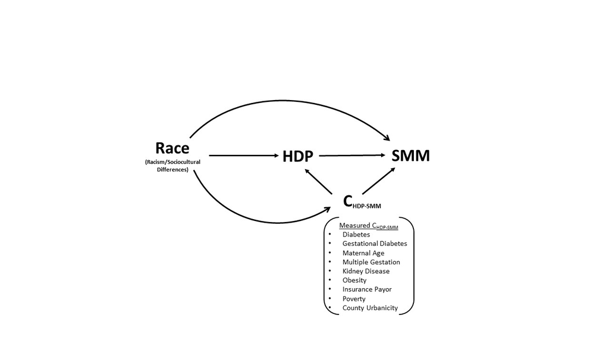

DAG for Decomposition of Racial Disparity in SMM

The code for these models was adapted from description of G-estimation methods and example code by *Naimi AI, Schnitzer ME, Moodie EEM, Bodnar LM. Mediation analysis for health disparities research. Am J Epidemiol. 2016;184(4):315-324. doi:10.1093/aje/kwv329.*

[Click for PDF available here](https://academic.oup.com/aje/article/184/4/315/2236917)

# Total Absolute Racial Disparity

Total Disparity: Excess 55.7 events per 10,000 delivery hospitalizations among NH Black women compared to NH White women.

```r
unadj.G.imp <- glm(formula = defG.flag ~ raceeth.1_0,
               data = model.dat2,
               family = binomial(link = "identity"))

te <- round(unadj.G.imp$coefficients[2]*10000, 1)

df <- confint(unadj.G.imp)
te.lci <- data.frame(round(df*10000, 1))[2,1]
te.uci <- data.frame(round(df*10000, 1))[2,2]

out.unadj <- cbind(te, te.lci, te.uci)

kableExtra::kable(out.unadj)
```

|  | te | te.lci | te.uci |
| --- | --- | --- | --- |
| raceeth.1_0 | 55.7 | 52.3 | 59.1 |

# Decomposition Method

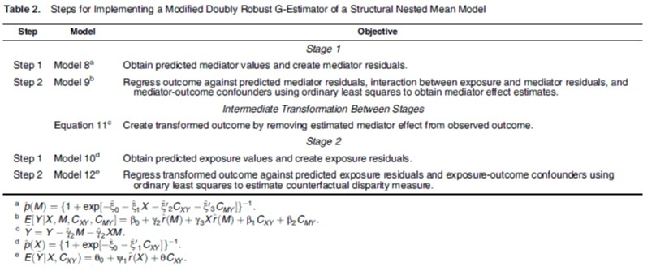

Steps described by Naimi et. al

## Stage 1

### Step 1

Obtain predicted mediator values and create mediator residuals.

HDP ~ Race + C_HDP.SMM

```r
# Mediator model: # m ~ x + c_xy + c_my
mM_HDP <- gest.HDP ~ raceeth.1_0 +
            rural.1_0 + insure_imp + age.NOT20to34.1_0 + ct.proportion.poverty_imp +
            multiplegest_imp + hdd.gestdiabetes.flag +
            hdd.renal.flag + hdd.prediabetes.flag + hdd.obesity.flag

# Model 8
mod_8.HDP <- glm(formula = mM_HDP,
                   family = binomial(link = "logit"),
                   data = data2)
```

Pull the predicted probabilities for the mediator

```r
data2$pred_med.HDP <- mod_8.HDP$fitted.values

head(data2$pred_med.HDP)
```

```
##          1          2          3          4          5          6
## 0.12480049 0.09623193 0.12569194 0.06647762 0.14128313 0.07815858
```

```r
range(data2$pred_med.HDP)
```

```
## [1] 0.05737744 0.93477656
```

Calculate the mediator residual: observed mediator value - predicted probability

```r
data2 <- data2 %>%
            mutate(mediator_resid.HDP.v2 = gest.HDP - pred_med.HDP)

head(data2$mediator_resid.HDP.v2)
```

```
##           1           2           3           4           5           6
## -0.12480049 -0.09623193 -0.12569194 -0.06647762 -0.14128313 -0.07815858
```

```r
range(data2$mediator_resid.HDP.v2)
```

```
## [1] -0.8432910  0.9426226
```

### Step 2

Regress outcome against predicted mediator residuals, interaction between exposure and mediator residuals, and mediator-outcome confounders using ordinary least squares to obtain mediator effect estimates.

SMM ~ Race + HDP.resid + Race:HDP.resid + C_HDP.SMM

```r
# Outcome model: # y ~ x + m.residual + x:m.residual + c_xy + c_my
mY <- defG.flag ~ raceeth.1_0 + mediator_resid.HDP.v2 + raceeth.1_0:mediator_resid.HDP.v2 +
                    rural.1_0 + insure_imp + age.NOT20to34.1_0 + ct.proportion.poverty_imp +
                    multiplegest_imp + hdd.gestdiabetes.flag +
                    hdd.renal.flag + hdd.prediabetes.flag + hdd.obesity.flag


mod_9 <- glm(formula = mY,
               family = gaussian(link = "identity"),
               data = data2)
```

## Intermediate Transformation Between Stages

Create transformed outcome by removing estimated mediator effect from observed outcome.

```r
data2 <- data2 %>%
          mutate(defG_trans = defG.flag -
                   (mod_9$coefficients["mediator_resid.HDP.v2"])*gest.HDP - # Mediator
                   (mod_9$coefficients["raceeth.1_0:mediator_resid.HDP.v2"])*gest.HDP*raceeth.1_0) # Exposure x Mediator

head(data2$defG_trans)
```

```
## [1] 1 0 0 0 0 0
```

```r
range(data2$defG_trans)
```

```
## [1] -0.02077321  1.00000000
```

## Stage 2

### Step 1

Obtain predicted exposure values and create exposure residuals.

Null model because there are no hypothesized confounders of Race-SMM (C_xy). mX is included for code completeness.

```r
# Exposure model: x ~ c_xy
mX <- raceeth.1_0 ~ NULL

mod_10 <- glm(formula = mX, # exposure
                family = binomial(link = "logit"),
                data = data2)
```

Pull predicted exposure values

```r
data2$pred_exp <- mod_10$fitted.values

table(data2$pred_exp)
```

```
##
## 0.431667718019272
##           1444171
```

Calculate exposure residuals

```r
data2 <- data2 %>%
            mutate(exp_resid.v2 = raceeth.1_0 - pred_exp)

table(data2$exp_resid.v2)
```

```
##
## -0.431667718019272  0.568332281980728
##             820769             623402
```

### Step 2

Regress transformed outcome against predicted exposure residuals and exposure-outcome confounders using ordinary least squares to estimate counterfactual disparity measure.

```r
mod_11 <- glm(formula = defG_trans ~ exp_resid.v2,
                family = gaussian(link = "identity"),
                data = data2)
```

## Output

```r
psi = mod_11$coefficients[2]*10000
stderr = sqrt(diag(vcov(mod_11)))[2]*10000
lci = round(psi - 1.96*stderr, 1)
uci = round(psi + 1.96*stderr, 1)
psi.r = round(psi, 1)

out = cbind(psi.r, lci, uci)

kableExtra::kable(out)
```

|  | psi.r | lci | uci |
| --- | --- | --- | --- |
| exp_resid.v2 | 41.1 | 37.8 | 44.4 |

Estimated CDE(No HDP): Excess 41.1 SMM events per 10,000 delivery hospitalizations among NH Black women compared to NH White women.